# IE 48B Group Project Report

## Forecasting Approach

In this part of the project, the system direction is classified by the forecasted value of net by using linear regression model. Linear regression model is improved by residuals analysis based on rpart regression tree. The regressors affect the residuals with highest value added as regressor of lm model.

```r
data = fread('bulk_imbalance.csv')
data_w = fread('2022-01-22_weather.csv')
head(data_w)
```

A data.table: 6 × 6

| date <date> | hour <int> | lat <dbl> | lon <dbl> | variable <chr> | value <dbl> |
| --- | --- | --- | --- | --- | --- |
| 2018-12-31 | 0 | 36.5 | 32.5 | DSWRF_surface | 0 |
| 2018-12-31 | 1 | 36.5 | 32.5 | DSWRF_surface | 0 |
| 2018-12-31 | 2 | 36.5 | 32.5 | DSWRF_surface | 0 |
| 2018-12-31 | 3 | 36.5 | 32.5 | DSWRF_surface | 0 |
| 2018-12-31 | 4 | 36.5 | 32.5 | DSWRF_surface | 0 |
| 2018-12-31 | 5 | 36.5 | 32.5 | DSWRF_surface | 0 |

There is some data transformassion on weather data. Every combination of attributes tranformed as a regressor.

```r
unified = str_c(data_w$variable,"_",data_w$lon,"_",data_w$lat )
data_w[,location := unified]
data_w= data_w[,c("date","hour","location","value")]
data_w = dcast(data_w,date+hour~location )
head(data_w)
```

A data.table: 6 × 44

| date <date> | hour <int> | DSWRF_surface_27_38.5 <dbl> | DSWRF_surface_28.75_41 <dbl> | DSWRF_surface_30.5_39.75 <dbl> | DSWRF_surface_32.5_36.5 <dbl> | DSWRF_surface_32.5_38 <dbl> | DSWRF_surface_33_40 <dbl> | DSWRF_surface_35.5_37 <dbl> | RH_2.m.above.ground_27_38.5 <dbl> | ⋯ | wdir_10m_32.5_38 <dbl> | wdir_10m_33_40 <dbl> | wdir_10m_35.5_37 <dbl> | ws_10m_27_38.5 <dbl> | ws_10m_28.75_41 <dbl> | ws_10m_30.5_39.75 <dbl> | ws_10m_32.5_36.5 <dbl> | ws_10m_32.5_38 <dbl> | ws_10m_33_40 <dbl> | ws_10m_35.5_37 <dbl> |
| --- | --- | --- | --- | --- | --- | --- | --- | --- | --- | --- | --- | --- | --- | --- | --- | --- | --- | --- | --- | --- |
| 2018-12-31 | 0 | 0 | 0 | 0 | 0 | 0 | 0 | 0 | 75.20000 | ⋯ | 231.8005 | 93.47636 | 179.5000 | 2.684959 | 3.150579 | 0.7788009 | 2.790017 | 0.8009606 | 0.9122336 | 2.355400 |
| 2018-12-31 | 1 | 0 | 0 | 0 | 0 | 0 | 0 | 0 | 76.03333 | ⋯ | 245.0924 | 90.29830 | 182.0823 | 2.672927 | 3.118881 | 1.0005702 | 2.725563 | 0.6506007 | 0.8931703 | 2.309428 |
| 2018-12-31 | 2 | 0 | 0 | 0 | 0 | 0 | 0 | 0 | 76.86667 | ⋯ | 258.3843 | 87.12025 | 184.6647 | 2.660895 | 3.087182 | 1.2223395 | 2.661109 | 0.5002407 | 0.8741070 | 2.263456 |
| 2018-12-31 | 3 | 0 | 0 | 0 | 0 | 0 | 0 | 0 | 77.70000 | ⋯ | 271.6762 | 83.94219 | 187.2471 | 2.648862 | 3.055483 | 1.4441088 | 2.596655 | 0.3498807 | 0.8550436 | 2.217484 |
| 2018-12-31 | 4 | 0 | 0 | 0 | 0 | 0 | 0 | 0 | 77.60000 | ⋯ | 217.6031 | 93.91665 | 186.7205 | 2.636125 | 2.920705 | 1.5497829 | 2.551815 | 0.3796237 | 0.7646836 | 2.207310 |
| 2018-12-31 | 5 | 0 | 0 | 0 | 0 | 0 | 0 | 0 | 77.50000 | ⋯ | 163.5301 | 103.89111 | 186.1939 | 2.623388 | 2.785928 | 1.6554570 | 2.506976 | 0.4093667 | 0.6743235 | 2.197135 |

```r
lm_data = merge(data[,c("date","hour","system_direction","net")],data_w, by = c("date","hour"))
head(lm_data)
```

A data.table: 6 × 46

| date <date> | hour <int> | system_direction <chr> | net <dbl> | DSWRF_surface_27_38.5 <dbl> | DSWRF_surface_28.75_41 <dbl> | DSWRF_surface_30.5_39.75 <dbl> | DSWRF_surface_32.5_36.5 <dbl> | DSWRF_surface_32.5_38 <dbl> | DSWRF_surface_33_40 <dbl> | ⋯ | wdir_10m_32.5_38 <dbl> | wdir_10m_33_40 <dbl> | wdir_10m_35.5_37 <dbl> | ws_10m_27_38.5 <dbl> | ws_10m_28.75_41 <dbl> | ws_10m_30.5_39.75 <dbl> | ws_10m_32.5_36.5 <dbl> | ws_10m_32.5_38 <dbl> | ws_10m_33_40 <dbl> | ws_10m_35.5_37 <dbl> |
| --- | --- | --- | --- | --- | --- | --- | --- | --- | --- | --- | --- | --- | --- | --- | --- | --- | --- | --- | --- | --- |
| 2019-01-01 | 0 | Negative | -1934.795 | 0 | 0 | 0 | 0 | 0 | 0 | ⋯ | 351.7313 | 280.4415 | 192.5959 | 5.151732 | 5.861836 | 3.913716 | 2.302671 | 1.784915 | 1.745607 | 3.057220 |
| 2019-01-01 | 1 | Negative | -750.866 | 0 | 0 | 0 | 0 | 0 | 0 | ⋯ | 350.1141 | 274.3150 | 192.2694 | 5.512422 | 6.254371 | 4.243639 | 2.443606 | 1.928927 | 1.962468 | 3.202298 |
| 2019-01-01 | 2 | Negative | -982.767 | 0 | 0 | 0 | 0 | 0 | 0 | ⋯ | 348.4970 | 268.1885 | 191.9429 | 5.873112 | 6.646906 | 4.573562 | 2.584541 | 2.072939 | 2.179329 | 3.347376 |
| 2019-01-01 | 3 | Negative | -764.620 | 0 | 0 | 0 | 0 | 0 | 0 | ⋯ | 346.8798 | 262.0619 | 191.6164 | 6.233802 | 7.039441 | 4.903485 | 2.725476 | 2.216951 | 2.396190 | 3.492454 |
| 2019-01-01 | 4 | Negative | -1233.289 | 0 | 0 | 0 | 0 | 0 | 0 | ⋯ | 337.7233 | 260.3688 | 191.7771 | 6.574972 | 7.291198 | 4.996934 | 2.755832 | 1.997965 | 2.522906 | 3.608525 |
| 2019-01-01 | 5 | Negative | -1469.061 | 0 | 0 | 0 | 0 | 0 | 0 | ⋯ | 328.5668 | 258.6757 | 191.9379 | 6.916141 | 7.542955 | 5.090382 | 2.786188 | 1.778979 | 2.649622 | 3.724596 |

```r
lm_data[,w_day:=as.character(wday(date))]
lm_data[,mon:=as.character(month(date))]
lm_data[,trnd:= 1:.N]
```

It is expected that last observations has effect on forecasted value therefore the lag of the net values added as potential regressors and corelation between them is calculated and shown below.

```r
for (i in c(36,48,60,72,24*7)){
  lm_data[,sprintf("lag_%s",i):= shift(net,i)]

}
```

```r
lm_data = lm_data[169:nrow(lm_data)]
```

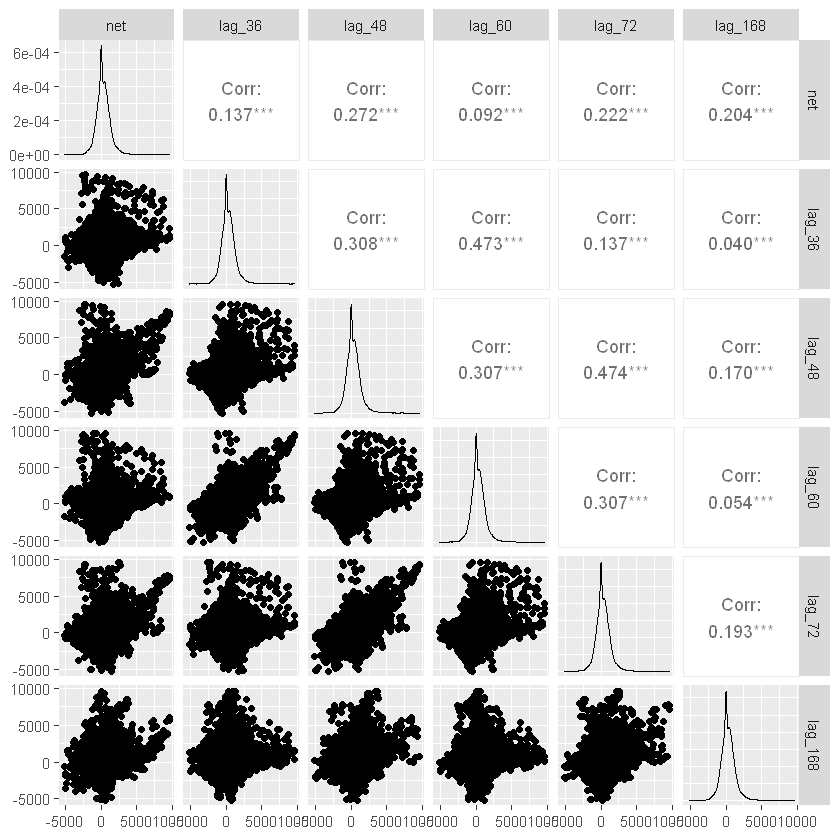

```r
ggpairs(lm_data[,c("net","lag_36","lag_48","lag_60","lag_72","lag_168")])
```

As seen above, the correlation values are significant.

Data is divided as test data and train data which used in model evaluation

```r
test_data = lm_data[date >= "2022-01-09"]
lm_data = lm_data[date < "2022-01-09"]
```

### Models

**Model 1**

The basic model is constructed by the seasonality and trend attributes.

```r
lm_base=lm(net~trnd+as.factor(w_day)+as.factor(mon)+as.factor(hour),lm_data)
summary(lm_base)
tmp=copy(lm_data)
tmp[, pred:= predict(lm_base, tmp)]
tmp[pred>= 50,c_pred:= "Positive"]
tmp[pred<=-50,c_pred:= "Negative"]
tmp[pred<50 & pred>-50,c_pred:= "Neutral"]
print("accuracy")
sum(tmp$system_direction==tmp$c_pred) / length(tmp$system_direction)
```

```
Call:
lm(formula = net ~ trnd + as.factor(w_day) + as.factor(mon) +
    as.factor(hour), data = lm_data)

Residuals:
    Min      1Q  Median      3Q     Max
-5480.2  -566.5   -26.8   513.6  8522.8

Coefficients:
                    Estimate Std. Error t value Pr(>|t|)
(Intercept)       -6.339e+02  4.023e+01 -15.757  < 2e-16 ***
trnd               2.473e-02  8.449e-04  29.267  < 2e-16 ***
as.factor(w_day)2  3.212e+02  2.296e+01  13.989  < 2e-16 ***
as.factor(w_day)3  3.969e+02  2.293e+01  17.314  < 2e-16 ***
as.factor(w_day)4  3.781e+02  2.293e+01  16.492  < 2e-16 ***
as.factor(w_day)5  4.222e+02  2.293e+01  18.412  < 2e-16 ***
as.factor(w_day)6  3.561e+02  2.293e+01  15.532  < 2e-16 ***
as.factor(w_day)7  2.301e+02  2.293e+01  10.036  < 2e-16 ***
as.factor(mon)10   5.449e+01  2.989e+01   1.823 0.068338 .
as.factor(mon)11   4.708e+01  3.022e+01   1.558 0.119300
as.factor(mon)12   4.143e+01  3.007e+01   1.377 0.168378
as.factor(mon)2    8.714e+01  3.038e+01   2.869 0.004126 **
as.factor(mon)3    2.393e+01  2.967e+01   0.807 0.419881
as.factor(mon)4   -1.177e+02  2.991e+01  -3.935 8.35e-05 ***
as.factor(mon)5   -3.949e+01  2.967e+01  -1.331 0.183097
as.factor(mon)6    1.587e+02  2.993e+01   5.303 1.15e-07 ***
as.factor(mon)7    3.946e+02  2.972e+01  13.280  < 2e-16 ***
as.factor(mon)8    4.085e+02  2.977e+01  13.725  < 2e-16 ***
as.factor(mon)9   -4.759e+01  3.007e+01  -1.583 0.113539
as.factor(hour)1   1.484e+02  4.242e+01   3.498 0.000469 ***
as.factor(hour)2   8.342e+01  4.242e+01   1.967 0.049231 *
as.factor(hour)3   2.923e+01  4.242e+01   0.689 0.490721
as.factor(hour)4  -3.075e+01  4.242e+01  -0.725 0.468444
as.factor(hour)5  -5.561e+01  4.242e+01  -1.311 0.189846
as.factor(hour)6  -1.611e+02  4.242e+01  -3.799 0.000145 ***
as.factor(hour)7  -1.264e+02  4.242e+01  -2.981 0.002880 **
as.factor(hour)8   4.016e+01  4.242e+01   0.947 0.343784
as.factor(hour)9   3.001e+02  4.242e+01   7.076 1.53e-12 ***
as.factor(hour)10  2.835e+02  4.242e+01   6.684 2.37e-11 ***
as.factor(hour)11  4.184e+02  4.242e+01   9.865  < 2e-16 ***
as.factor(hour)12  2.193e+02  4.242e+01   5.171 2.35e-07 ***
as.factor(hour)13  1.483e+02  4.242e+01   3.497 0.000471 ***
as.factor(hour)14  4.124e+02  4.242e+01   9.722  < 2e-16 ***
as.factor(hour)15  4.029e+02  4.242e+01   9.500  < 2e-16 ***
as.factor(hour)16  3.395e+02  4.242e+01   8.005 1.25e-15 ***
as.factor(hour)17  4.334e+02  4.242e+01  10.219  < 2e-16 ***
as.factor(hour)18  4.142e+02  4.242e+01   9.765  < 2e-16 ***
as.factor(hour)19  3.870e+02  4.242e+01   9.125  < 2e-16 ***
as.factor(hour)20  3.785e+02  4.242e+01   8.924  < 2e-16 ***
as.factor(hour)21  4.051e+02  4.242e+01   9.551  < 2e-16 ***
as.factor(hour)22  2.859e+02  4.242e+01   6.741 1.61e-11 ***
as.factor(hour)23  2.074e+02  4.242e+01   4.889 1.02e-06 ***
---
Signif. codes:  0 '***' 0.001 '**' 0.01 '*' 0.05 '.' 0.1 ' ' 1

Residual standard error: 993.4 on 26286 degrees of freedom
Multiple R-squared:  0.106,	Adjusted R-squared:  0.1046
F-statistic: 76.02 on 41 and 26286 DF,  p-value: < 2.2e-16
```

```
[1] "accuracy"
```

0.54117289577636

**Model 2**

By learning from derivatives the path is added as regressors.

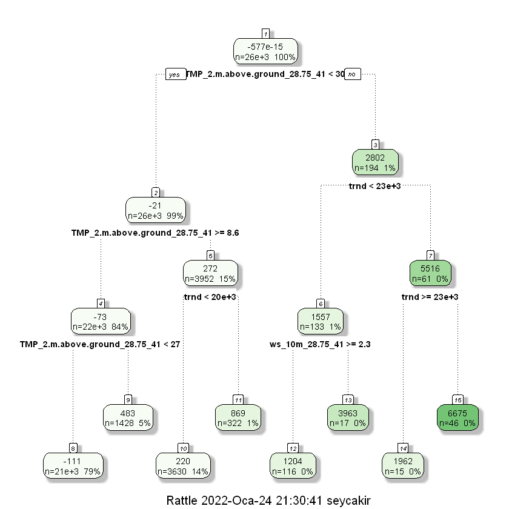

```r
tmp[,residuals:= net-pred]
df = tmp[,-c("net","date","pred","c_pred","system_direction")]
model_1 = rpart(residuals ~. ,df, control = rpart.control(maxdepth = 3,cp = 0) )
fancyRpartPlot(model_1)
```

```r
tmp[,A:= as.numeric(TMP_2.m.above.ground_28.75_41   >= 30.451)]
tmp[, B:= as.numeric(trnd >= 22669.5)]
tmp[,C:= as.numeric(trnd   < 22817.5)]
lm_base_2 = lm(net~ trnd + factor(hour) + factor(mon) + factor(w_day) + A:B:C,tmp)
summary(lm_base_2)
tmp[,pred := predict(lm_base_2,tmp)]
tmp[pred>= 50,c_pred:= "Positive"]
tmp[pred<=-50,c_pred:= "Negative"]
tmp[pred<50 & pred>-50,c_pred:= "Neutral"]
tmp[,residuals:= net-pred]
print("Accuracy")
sum(tmp$system_direction==tmp$c_pred) / length(tmp$system_direction)
```

```
Call:
lm(formula = net ~ trnd + factor(hour) + factor(mon) + factor(w_day) +
    A:B:C, data = tmp)

Residuals:
    Min      1Q  Median      3Q     Max
-5485.8  -553.4   -24.0   515.5  7958.7

Coefficients:
                 Estimate Std. Error t value Pr(>|t|)
(Intercept)    -5.874e+02  3.857e+01 -15.228  < 2e-16 ***
trnd            2.279e-02  8.109e-04  28.104  < 2e-16 ***
factor(hour)1   1.484e+02  4.066e+01   3.650 0.000263 ***
factor(hour)2   8.342e+01  4.066e+01   2.052 0.040206 *
factor(hour)3   2.924e+01  4.066e+01   0.719 0.472095
factor(hour)4  -3.074e+01  4.066e+01  -0.756 0.449565
factor(hour)5  -5.560e+01  4.066e+01  -1.367 0.171492
factor(hour)6  -1.611e+02  4.066e+01  -3.963 7.42e-05 ***
factor(hour)7  -1.264e+02  4.066e+01  -3.109 0.001879 **
factor(hour)8   4.017e+01  4.066e+01   0.988 0.323157
factor(hour)9   3.001e+02  4.066e+01   7.382 1.61e-13 ***
factor(hour)10  2.835e+02  4.066e+01   6.973 3.17e-12 ***
factor(hour)11  3.997e+02  4.066e+01   9.831  < 2e-16 ***
factor(hour)12  1.944e+02  4.066e+01   4.780 1.76e-06 ***
factor(hour)13  1.171e+02  4.066e+01   2.880 0.003975 **
factor(hour)14  3.812e+02  4.066e+01   9.373  < 2e-16 ***
factor(hour)15  3.717e+02  4.066e+01   9.142  < 2e-16 ***
factor(hour)16  3.083e+02  4.066e+01   7.582 3.51e-14 ***
factor(hour)17  4.022e+02  4.066e+01   9.891  < 2e-16 ***
factor(hour)18  3.830e+02  4.066e+01   9.418  < 2e-16 ***
factor(hour)19  3.683e+02  4.066e+01   9.058  < 2e-16 ***
factor(hour)20  3.660e+02  4.066e+01   9.003  < 2e-16 ***
factor(hour)21  3.927e+02  4.066e+01   9.657  < 2e-16 ***
factor(hour)22  2.735e+02  4.066e+01   6.726 1.78e-11 ***
factor(hour)23  2.074e+02  4.066e+01   5.102 3.39e-07 ***
factor(mon)10   6.300e+01  2.865e+01   2.199 0.027900 *
factor(mon)11   5.698e+01  2.897e+01   1.967 0.049222 *
factor(mon)12   5.316e+01  2.883e+01   1.844 0.065208 .
factor(mon)2    8.423e+01  2.912e+01   2.893 0.003823 **
factor(mon)3    2.240e+01  2.844e+01   0.788 0.430886
factor(mon)4   -1.172e+02  2.867e+01  -4.089 4.34e-05 ***
factor(mon)5   -3.831e+01  2.844e+01  -1.347 0.177938
factor(mon)6    1.615e+02  2.870e+01   5.628 1.84e-08 ***
factor(mon)7    3.993e+02  2.849e+01  14.016  < 2e-16 ***
factor(mon)8    2.728e+02  2.867e+01   9.514  < 2e-16 ***
factor(mon)9   -4.028e+01  2.882e+01  -1.397 0.162348
factor(w_day)2  3.029e+02  2.201e+01  13.760  < 2e-16 ***
factor(w_day)3  3.813e+02  2.198e+01  17.348  < 2e-16 ***
factor(w_day)4  3.617e+02  2.198e+01  16.453  < 2e-16 ***
factor(w_day)5  3.993e+02  2.199e+01  18.163  < 2e-16 ***
factor(w_day)6  3.406e+02  2.198e+01  15.498  < 2e-16 ***
factor(w_day)7  2.302e+02  2.198e+01  10.474  < 2e-16 ***
A:B:C           6.854e+03  1.423e+02  48.177  < 2e-16 ***
---
Signif. codes:  0 '***' 0.001 '**' 0.01 '*' 0.05 '.' 0.1 ' ' 1

Residual standard error: 952.2 on 26285 degrees of freedom
Multiple R-squared:  0.1785,	Adjusted R-squared:  0.1772
F-statistic:   136 on 42 and 26285 DF,  p-value: < 2.2e-16
```

```
[1] "Accuracy"
```

0.540641142509875

**Model 3**

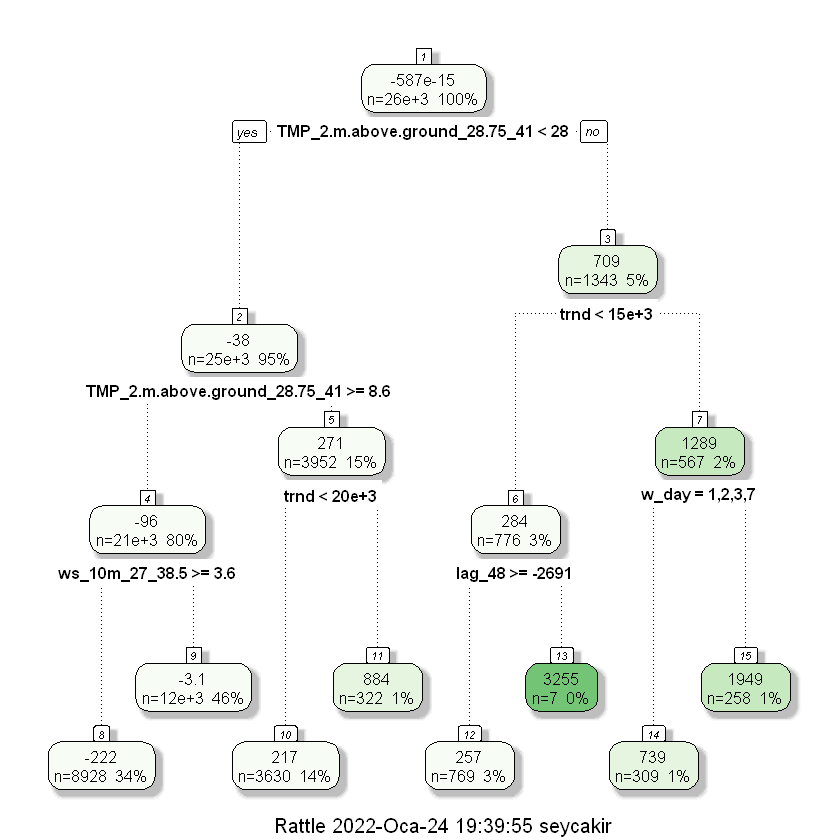

```r
df_2  = tmp[,-c("net","date","pred","c_pred","system_direction")]
model_2 = rpart(residuals ~.-A-B-C ,df_2, control = rpart.control(maxdepth = 3,cp = 0) )
fancyRpartPlot(model_2)
```

```r
tmp[,D:= as.numeric(TMP_2.m.above.ground_28.75_41   >= 27.6025 ) ]
tmp[,E:=  as.numeric( trnd    >= 14607.5) ]
tmp[,F:=as.numeric(w_day %in% c(4,5,6)) ]
lm_base_3 = lm(net~ trnd + factor(hour) + factor(mon) + factor(w_day) + A:B:C + D:E:F,tmp)
summary(lm_base_3)
tmp[,pred := predict(lm_base_3,tmp)]
tmp[pred>= 50,c_pred:= "Positive"]
tmp[pred<=-50,c_pred:= "Negative"]
tmp[pred<50 & pred>-50,c_pred:= "Neutral"]
tmp[,residuals:= net-pred]
print("Accuracy")
sum(tmp$system_direction==tmp$c_pred) / length(tmp$system_direction)
```

```
Call:
lm(formula = net ~ trnd + factor(hour) + factor(mon) + factor(w_day) +
    A:B:C + D:E:F, data = tmp)

Residuals:
    Min      1Q  Median      3Q     Max
-5518.1  -534.8   -13.3   520.5  6439.7

Coefficients:
                 Estimate Std. Error t value Pr(>|t|)
(Intercept)    -5.191e+02  3.770e+01 -13.767  < 2e-16 ***
trnd            1.974e-02  7.961e-04  24.793  < 2e-16 ***
factor(hour)1   1.525e+02  3.969e+01   3.841 0.000123 ***
factor(hour)2   8.750e+01  3.969e+01   2.205 0.027490 *
factor(hour)3   3.332e+01  3.969e+01   0.840 0.401189
factor(hour)4  -2.666e+01  3.969e+01  -0.672 0.501805
factor(hour)5  -4.947e+01  3.969e+01  -1.246 0.212594
factor(hour)6  -1.550e+02  3.969e+01  -3.905 9.43e-05 ***
factor(hour)7  -1.203e+02  3.969e+01  -3.030 0.002445 **
factor(hour)8   4.427e+01  3.969e+01   1.115 0.264694
factor(hour)9   2.961e+02  3.969e+01   7.460 8.92e-14 ***
factor(hour)10  2.673e+02  3.969e+01   6.733 1.69e-11 ***
factor(hour)11  3.746e+02  3.970e+01   9.436  < 2e-16 ***
factor(hour)12  1.581e+02  3.971e+01   3.982 6.85e-05 ***
factor(hour)13  7.995e+01  3.971e+01   2.014 0.044066 *
factor(hour)14  3.419e+02  3.971e+01   8.611  < 2e-16 ***
factor(hour)15  3.285e+02  3.971e+01   8.271  < 2e-16 ***
factor(hour)16  2.650e+02  3.971e+01   6.674 2.54e-11 ***
factor(hour)17  3.651e+02  3.971e+01   9.194  < 2e-16 ***
factor(hour)18  3.560e+02  3.970e+01   8.967  < 2e-16 ***
factor(hour)19  3.452e+02  3.970e+01   8.697  < 2e-16 ***
factor(hour)20  3.439e+02  3.970e+01   8.663  < 2e-16 ***
factor(hour)21  3.848e+02  3.969e+01   9.694  < 2e-16 ***
factor(hour)22  2.717e+02  3.969e+01   6.845 7.82e-12 ***
factor(hour)23  2.055e+02  3.969e+01   5.177 2.27e-07 ***
factor(mon)10   7.210e+01  2.797e+01   2.578 0.009957 **
factor(mon)11   7.083e+01  2.829e+01   2.504 0.012284 *
factor(mon)12   7.081e+01  2.815e+01   2.516 0.011884 *
factor(mon)2    7.869e+01  2.842e+01   2.768 0.005638 **
factor(mon)3    1.832e+01  2.776e+01   0.660 0.509444
factor(mon)4   -1.174e+02  2.799e+01  -4.196 2.73e-05 ***
factor(mon)5   -3.690e+01  2.776e+01  -1.329 0.183707
factor(mon)6    1.447e+02  2.802e+01   5.163 2.44e-07 ***
factor(mon)7    3.011e+02  2.794e+01  10.775  < 2e-16 ***
factor(mon)8    1.938e+02  2.807e+01   6.904 5.18e-12 ***
factor(mon)9   -4.925e+01  2.814e+01  -1.750 0.080068 .
factor(w_day)2  3.069e+02  2.149e+01  14.279  < 2e-16 ***
factor(w_day)3  3.838e+02  2.146e+01  17.889  < 2e-16 ***
factor(w_day)4  3.057e+02  2.151e+01  14.209  < 2e-16 ***
factor(w_day)5  3.557e+02  2.150e+01  16.545  < 2e-16 ***
factor(w_day)6  2.975e+02  2.149e+01  13.844  < 2e-16 ***
factor(w_day)7  2.309e+02  2.145e+01  10.764  < 2e-16 ***
A:B:C           5.633e+03  1.429e+02  39.411  < 2e-16 ***
D:E:F           2.235e+03  6.197e+01  36.060  < 2e-16 ***
---
Signif. codes:  0 '***' 0.001 '**' 0.01 '*' 0.05 '.' 0.1 ' ' 1

Residual standard error: 929.5 on 26284 degrees of freedom
Multiple R-squared:  0.2173,	Adjusted R-squared:  0.216
F-statistic: 169.7 on 43 and 26284 DF,  p-value: < 2.2e-16
```

```
[1] "Accuracy"
```

0.540033424491036

**Model 4**

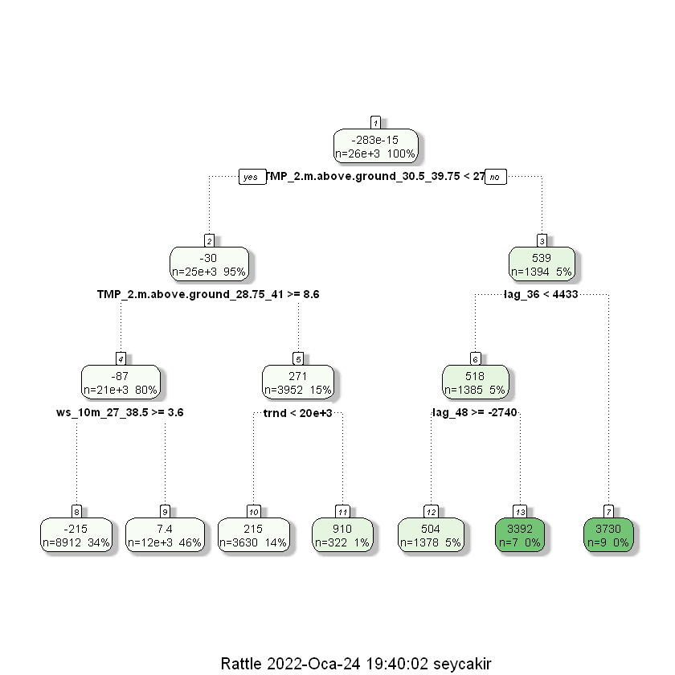

```r
df_3 = tmp[,-c("net","date","pred","c_pred","system_direction","A","B","C","D","E","F")]
model_3 = rpart(residuals ~.,df_3, control = rpart.control(maxdepth = 3,cp = 0) )
fancyRpartPlot(model_3)
```

```r
tmp[, H:= as.numeric(TMP_2.m.above.ground_30.5_39.75 >= 26.989) ]
tmp[,G:= as.numeric(lag_36       >= 4433.206 )  ]
lm_base_4 = lm(net~ trnd + factor(hour) + factor(mon) + factor(w_day) + A:B:C + D:E:F + H:G,tmp)
summary(lm_base_4)
tmp[,pred := predict(lm_base_4,tmp)]
tmp[pred>= 50,c_pred:= "Positive"]
tmp[pred<=-50,c_pred:= "Negative"]
tmp[pred<50 & pred>-50,c_pred:= "Neutral"]
tmp[,residuals:= net-pred]
print("Accuracy")
sum(tmp$system_direction==tmp$c_pred) / length(tmp$system_direction)
```

```
Call:
lm(formula = net ~ trnd + factor(hour) + factor(mon) + factor(w_day) +
    A:B:C + D:E:F + H:G, data = tmp)

Residuals:
    Min      1Q  Median      3Q     Max
-5516.3  -533.4   -13.0   521.8  6450.1

Coefficients:
                 Estimate Std. Error t value Pr(>|t|)
(Intercept)    -5.168e+02  3.760e+01 -13.746  < 2e-16 ***
trnd            1.965e-02  7.939e-04  24.750  < 2e-16 ***
factor(hour)1   1.524e+02  3.958e+01   3.850 0.000119 ***
factor(hour)2   8.740e+01  3.958e+01   2.208 0.027237 *
factor(hour)3   3.322e+01  3.958e+01   0.839 0.401306
factor(hour)4  -2.676e+01  3.958e+01  -0.676 0.498979
factor(hour)5  -4.963e+01  3.958e+01  -1.254 0.209913
factor(hour)6  -1.552e+02  3.958e+01  -3.920 8.87e-05 ***
factor(hour)7  -1.204e+02  3.958e+01  -3.043 0.002347 **
factor(hour)8   4.417e+01  3.958e+01   1.116 0.264448
factor(hour)9   2.927e+02  3.958e+01   7.396 1.45e-13 ***
factor(hour)10  2.573e+02  3.959e+01   6.498 8.28e-11 ***
factor(hour)11  3.652e+02  3.959e+01   9.224  < 2e-16 ***
factor(hour)12  1.561e+02  3.959e+01   3.943 8.07e-05 ***
factor(hour)13  8.160e+01  3.960e+01   2.061 0.039332 *
factor(hour)14  3.436e+02  3.960e+01   8.678  < 2e-16 ***
factor(hour)15  3.303e+02  3.960e+01   8.339  < 2e-16 ***
factor(hour)16  2.668e+02  3.960e+01   6.738 1.64e-11 ***
factor(hour)17  3.667e+02  3.960e+01   9.261  < 2e-16 ***
factor(hour)18  3.574e+02  3.959e+01   9.027  < 2e-16 ***
factor(hour)19  3.462e+02  3.959e+01   8.747  < 2e-16 ***
factor(hour)20  3.447e+02  3.958e+01   8.709  < 2e-16 ***
factor(hour)21  3.818e+02  3.958e+01   9.646  < 2e-16 ***
factor(hour)22  2.720e+02  3.958e+01   6.873 6.45e-12 ***
factor(hour)23  2.055e+02  3.958e+01   5.193 2.09e-07 ***
factor(mon)10   7.259e+01  2.789e+01   2.603 0.009259 **
factor(mon)11   7.127e+01  2.821e+01   2.527 0.011519 *
factor(mon)12   7.127e+01  2.807e+01   2.539 0.011113 *
factor(mon)2    7.852e+01  2.834e+01   2.770 0.005606 **
factor(mon)3    1.822e+01  2.769e+01   0.658 0.510521
factor(mon)4   -1.175e+02  2.791e+01  -4.209 2.57e-05 ***
factor(mon)5   -3.682e+01  2.768e+01  -1.330 0.183490
factor(mon)6    1.452e+02  2.794e+01   5.197 2.04e-07 ***
factor(mon)7    2.988e+02  2.786e+01  10.723  < 2e-16 ***
factor(mon)8    1.892e+02  2.800e+01   6.757 1.44e-11 ***
factor(mon)9   -4.852e+01  2.806e+01  -1.729 0.083797 .
factor(w_day)2  3.072e+02  2.143e+01  14.336  < 2e-16 ***
factor(w_day)3  3.841e+02  2.140e+01  17.951  < 2e-16 ***
factor(w_day)4  3.054e+02  2.145e+01  14.233  < 2e-16 ***
factor(w_day)5  3.573e+02  2.144e+01  16.666  < 2e-16 ***
factor(w_day)6  2.919e+02  2.143e+01  13.616  < 2e-16 ***
factor(w_day)7  2.309e+02  2.139e+01  10.795  < 2e-16 ***
H:G             3.804e+03  3.121e+02  12.192  < 2e-16 ***
A:B:C           5.506e+03  1.429e+02  38.529  < 2e-16 ***
D:E:F           2.179e+03  6.196e+01  35.162  < 2e-16 ***
---
Signif. codes:  0 '***' 0.001 '**' 0.01 '*' 0.05 '.' 0.1 ' ' 1

Residual standard error: 926.9 on 26283 degrees of freedom
Multiple R-squared:  0.2217,	Adjusted R-squared:  0.2204
F-statistic: 170.1 on 44 and 26283 DF,  p-value: < 2.2e-16
```

```
[1] "Accuracy"
```

0.539615618353084

Sınce the improvement is lower than 0.1 in asjusted R-squared value and accuracy of model is lower than previous one the improvment process is stopped in here. And lm_base model is used as prediction since it has the highest accuracy.

### Prediction by Forecasting Model

```r
test_data[system_direction == ""]$system_direction = "Positive"
test_data[, pred := predict(lm_base, test_data)]
```

```r
test_data[pred>= 50,c_pred:= "Positive"]
test_data[pred<=-50,c_pred:= "Negative"]
test_data[pred<50 & pred>-50,c_pred:= "Neutral"]
```

```r
test_data = test_data[hour %in% 12:23]
print("Accuracy")
sum(test_data$system_direction==test_data$c_pred) / length(test_data$system_direction)
```

```
[1] "Accuracy"
```

0.827380952380952

**Predictions**

```r
test_data[,c("date","hour","system_direction","c_pred")]
```

A data.table: 168 × 4

| date <date> | hour <int> | system_direction <chr> | c_pred <chr> |
| --- | --- | --- | --- |
| 2022-01-09 | 12 | Neutral | Positive |
| 2022-01-09 | 13 | Neutral | Positive |
| 2022-01-09 | 14 | Neutral | Positive |
| 2022-01-09 | 15 | Positive | Positive |
| 2022-01-09 | 16 | Positive | Positive |
| 2022-01-09 | 17 | Positive | Positive |
| 2022-01-09 | 18 | Positive | Positive |
| 2022-01-09 | 19 | Positive | Positive |
| 2022-01-09 | 20 | Positive | Positive |
| 2022-01-09 | 21 | Positive | Positive |
| 2022-01-09 | 22 | Positive | Positive |
| 2022-01-09 | 23 | Positive | Positive |
| 2022-01-10 | 12 | Negative | Positive |
| 2022-01-10 | 13 | Positive | Positive |
| 2022-01-10 | 14 | Positive | Positive |
| 2022-01-10 | 15 | Positive | Positive |
| 2022-01-10 | 16 | Positive | Positive |
| 2022-01-10 | 17 | Positive | Positive |
| 2022-01-10 | 18 | Positive | Positive |
| 2022-01-10 | 19 | Negative | Positive |
| 2022-01-10 | 20 | Negative | Positive |
| 2022-01-10 | 21 | Negative | Positive |
| 2022-01-10 | 22 | Positive | Positive |
| 2022-01-10 | 23 | Positive | Positive |
| 2022-01-11 | 12 | Positive | Positive |
| 2022-01-11 | 13 | Positive | Positive |
| 2022-01-11 | 14 | Positive | Positive |
| 2022-01-11 | 15 | Positive | Positive |
| 2022-01-11 | 16 | Positive | Positive |
| 2022-01-11 | 17 | Positive | Positive |
| ⋮ | ⋮ | ⋮ | ⋮ |
| 2022-01-20 | 18 | Positive | Positive |
| 2022-01-20 | 19 | Positive | Positive |
| 2022-01-20 | 20 | Positive | Positive |
| 2022-01-20 | 21 | Positive | Positive |
| 2022-01-20 | 22 | Positive | Positive |
| 2022-01-20 | 23 | Positive | Positive |
| 2022-01-21 | 12 | Positive | Positive |
| 2022-01-21 | 13 | Positive | Positive |
| 2022-01-21 | 14 | Positive | Positive |
| 2022-01-21 | 15 | Positive | Positive |
| 2022-01-21 | 16 | Positive | Positive |
| 2022-01-21 | 17 | Positive | Positive |
| 2022-01-21 | 18 | Positive | Positive |
| 2022-01-21 | 19 | Positive | Positive |
| 2022-01-21 | 20 | Positive | Positive |
| 2022-01-21 | 21 | Positive | Positive |
| 2022-01-21 | 22 | Positive | Positive |
| 2022-01-21 | 23 | Positive | Positive |
| 2022-01-22 | 12 | Positive | Positive |
| 2022-01-22 | 13 | Positive | Positive |
| 2022-01-22 | 14 | Positive | Positive |
| 2022-01-22 | 15 | Positive | Positive |
| 2022-01-22 | 16 | Positive | Positive |
| 2022-01-22 | 17 | Positive | Positive |
| 2022-01-22 | 18 | Positive | Positive |
| 2022-01-22 | 19 | Positive | Positive |
| 2022-01-22 | 20 | Positive | Positive |
| 2022-01-22 | 21 | Positive | Positive |
| 2022-01-22 | 22 | Positive | Positive |
| 2022-01-22 | 23 | Positive | Positive |

# Results

**Time-series Representation and k-nn Classification based on Different Distance Aproaches**

As mentioned above, by using time series representation and k-nn classification based on different approach, It is tried to find best representation technique, best k value and distance approcah by getting highest average accuracy. In the end, predictions based on approach give highest accuracy in train data.

However, the prediction accuracy was much smaller than training accuracy.

*Train Data Mean Accuracy*

```r
mean(best_results$avg_acc)
```

0.804487617487617

*Test Data Mean Accuracy*

```r
mean(predictions$acc)
```

0.708333333333333

**Forecasting Approach**

In Forecasting Approach, the net value is tried to be forecasted and after forecasting, the net value classified. In the train data Forecasting Approach, Accuracy value was lower than Time-series Representation and k-nn Classification based on Different Distance Aproaches. However, In test data, It give better results.

*Train Data Mean Accuracy*

0.54117289577636

*Test Data Mean Accuracy*

```r
sum(test_data$system_direction==test_data$c_pred) / length(test_data$system_direction)
```

0.827380952380952

**Baseline Methods**

```r
data = fread("bulk_imbalance.csv")
df= copy(data[,c("date","hour","net","system_direction")])
df[system_direction == ""]$system_direction = "Positive"

for( i in c(48,168)){
    df[, sprintf("lag_%s",i) := shift(system_direction, i)]
}
head(df[169:nrow(df)])
```

A data.table: 6 × 6

| date <date> | hour <int> | net <dbl> | system_direction <chr> | lag_48 <chr> | lag_168 <chr> |
| --- | --- | --- | --- | --- | --- |
| 2019-01-08 | 0 | -464.400 | Negative | Negative | Negative |
| 2019-01-08 | 1 | -8.662 | Neutral | Positive | Negative |
| 2019-01-08 | 2 | 70.445 | Positive | Positive | Negative |
| 2019-01-08 | 3 | 60.549 | Positive | Negative | Negative |
| 2019-01-08 | 4 | 43.140 | Neutral | Neutral | Negative |
| 2019-01-08 | 5 | 25.490 | Neutral | Neutral | Negative |

**Baseline method 1**

Predictions based on 48 hours before prediction time. (Lag 48)

```r
pred_baseline1 = df[hour >= 12 & date >= "2022-01-09",-6]
pred_baseline1
```

A data.table: 168 × 5

| date <date> | hour <int> | net <dbl> | system_direction <chr> | lag_48 <chr> |
| --- | --- | --- | --- | --- |
| 2022-01-09 | 12 | 0.000 | Neutral | Positive |
| 2022-01-09 | 13 | 0.000 | Neutral | Positive |
| 2022-01-09 | 14 | 32.647 | Neutral | Positive |
| 2022-01-09 | 15 | 127.917 | Positive | Positive |
| 2022-01-09 | 16 | 450.247 | Positive | Positive |
| 2022-01-09 | 17 | 278.483 | Positive | Positive |
| 2022-01-09 | 18 | 170.920 | Positive | Positive |
| 2022-01-09 | 19 | 393.789 | Positive | Positive |
| 2022-01-09 | 20 | 617.549 | Positive | Positive |
| 2022-01-09 | 21 | 993.900 | Positive | Positive |
| 2022-01-09 | 22 | 1208.517 | Positive | Negative |
| 2022-01-09 | 23 | 1354.237 | Positive | Positive |
| 2022-01-10 | 12 | -274.507 | Negative | Positive |
| 2022-01-10 | 13 | 375.192 | Positive | Positive |
| 2022-01-10 | 14 | 998.611 | Positive | Positive |
| 2022-01-10 | 15 | 1542.698 | Positive | Positive |
| 2022-01-10 | 16 | 1952.723 | Positive | Positive |
| 2022-01-10 | 17 | 874.938 | Positive | Positive |
| 2022-01-10 | 18 | 598.624 | Positive | Positive |
| 2022-01-10 | 19 | -212.517 | Negative | Positive |
| 2022-01-10 | 20 | -149.368 | Negative | Positive |
| 2022-01-10 | 21 | -460.217 | Negative | Positive |
| 2022-01-10 | 22 | 1093.374 | Positive | Positive |
| 2022-01-10 | 23 | 323.775 | Positive | Positive |
| 2022-01-11 | 12 | 2877.114 | Positive | Neutral |
| 2022-01-11 | 13 | 2289.469 | Positive | Neutral |
| 2022-01-11 | 14 | 2358.886 | Positive | Neutral |
| 2022-01-11 | 15 | 2386.370 | Positive | Positive |
| 2022-01-11 | 16 | 2717.139 | Positive | Positive |
| 2022-01-11 | 17 | 3889.274 | Positive | Positive |
| ⋮ | ⋮ | ⋮ | ⋮ | ⋮ |
| 2022-01-20 | 18 | 1620.613 | Positive | Positive |
| 2022-01-20 | 19 | 2043.429 | Positive | Positive |
| 2022-01-20 | 20 | 2171.459 | Positive | Positive |
| 2022-01-20 | 21 | 2981.076 | Positive | Positive |
| 2022-01-20 | 22 | 2627.598 | Positive | Positive |
| 2022-01-20 | 23 | 2306.741 | Positive | Positive |
| 2022-01-21 | 12 | 2551.120 | Positive | Positive |
| 2022-01-21 | 13 | 2287.672 | Positive | Positive |
| 2022-01-21 | 14 | 2577.379 | Positive | Positive |
| 2022-01-21 | 15 | 3845.232 | Positive | Positive |
| 2022-01-21 | 16 | 4529.034 | Positive | Positive |
| 2022-01-21 | 17 | 4491.918 | Positive | Positive |
| 2022-01-21 | 18 | 4161.272 | Positive | Positive |
| 2022-01-21 | 19 | 3967.694 | Positive | Positive |
| 2022-01-21 | 20 | 4519.441 | Positive | Positive |
| 2022-01-21 | 21 | 3549.844 | Positive | Positive |
| 2022-01-21 | 22 | 3907.912 | Positive | Positive |
| 2022-01-21 | 23 | 4660.870 | Positive | Positive |
| 2022-01-22 | 12 | 0.000 | Positive | Positive |
| 2022-01-22 | 13 | 0.000 | Positive | Positive |
| 2022-01-22 | 14 | 0.000 | Positive | Positive |
| 2022-01-22 | 15 | 0.000 | Positive | Positive |
| 2022-01-22 | 16 | 0.000 | Positive | Positive |
| 2022-01-22 | 17 | 0.000 | Positive | Positive |
| 2022-01-22 | 18 | 0.000 | Positive | Positive |
| 2022-01-22 | 19 | 0.000 | Positive | Positive |
| 2022-01-22 | 20 | 0.000 | Positive | Positive |
| 2022-01-22 | 21 | 0.000 | Positive | Positive |
| 2022-01-22 | 22 | 0.000 | Positive | Positive |
| 2022-01-22 | 23 | 0.000 | Positive | Positive |

*Test Accuarcy of basline 1*

```r
sum(pred_baseline1$system_direction==pred_baseline1$lag_48) / length(pred_baseline1$system_direction)
```

0.69047619047619

**Baseline Method 2**

Predictions based on last week same hours before prediction time. (Lag 168)

```r
pred_baseline2 = df[hour >= 12 & date >= "2022-01-09",-5]
pred_baseline2
```

A data.table: 168 × 5

| date <date> | hour <int> | net <dbl> | system_direction <chr> | lag_168 <chr> |
| --- | --- | --- | --- | --- |
| 2022-01-09 | 12 | 0.000 | Neutral | Negative |
| 2022-01-09 | 13 | 0.000 | Neutral | Negative |
| 2022-01-09 | 14 | 32.647 | Neutral | Neutral |
| 2022-01-09 | 15 | 127.917 | Positive | Positive |
| 2022-01-09 | 16 | 450.247 | Positive | Positive |
| 2022-01-09 | 17 | 278.483 | Positive | Neutral |
| 2022-01-09 | 18 | 170.920 | Positive | Negative |
| 2022-01-09 | 19 | 393.789 | Positive | Negative |
| 2022-01-09 | 20 | 617.549 | Positive | Negative |
| 2022-01-09 | 21 | 993.900 | Positive | Positive |
| 2022-01-09 | 22 | 1208.517 | Positive | Positive |
| 2022-01-09 | 23 | 1354.237 | Positive | Positive |
| 2022-01-10 | 12 | -274.507 | Negative | Positive |
| 2022-01-10 | 13 | 375.192 | Positive | Negative |
| 2022-01-10 | 14 | 998.611 | Positive | Positive |
| 2022-01-10 | 15 | 1542.698 | Positive | Positive |
| 2022-01-10 | 16 | 1952.723 | Positive | Positive |
| 2022-01-10 | 17 | 874.938 | Positive | Positive |
| 2022-01-10 | 18 | 598.624 | Positive | Positive |
| 2022-01-10 | 19 | -212.517 | Negative | Negative |
| 2022-01-10 | 20 | -149.368 | Negative | Negative |
| 2022-01-10 | 21 | -460.217 | Negative | Negative |
| 2022-01-10 | 22 | 1093.374 | Positive | Positive |
| 2022-01-10 | 23 | 323.775 | Positive | Positive |
| 2022-01-11 | 12 | 2877.114 | Positive | Positive |
| 2022-01-11 | 13 | 2289.469 | Positive | Positive |
| 2022-01-11 | 14 | 2358.886 | Positive | Positive |
| 2022-01-11 | 15 | 2386.370 | Positive | Positive |
| 2022-01-11 | 16 | 2717.139 | Positive | Positive |
| 2022-01-11 | 17 | 3889.274 | Positive | Positive |
| ⋮ | ⋮ | ⋮ | ⋮ | ⋮ |
| 2022-01-20 | 18 | 1620.613 | Positive | Positive |
| 2022-01-20 | 19 | 2043.429 | Positive | Positive |
| 2022-01-20 | 20 | 2171.459 | Positive | Positive |
| 2022-01-20 | 21 | 2981.076 | Positive | Positive |
| 2022-01-20 | 22 | 2627.598 | Positive | Positive |
| 2022-01-20 | 23 | 2306.741 | Positive | Positive |
| 2022-01-21 | 12 | 2551.120 | Positive | Negative |
| 2022-01-21 | 13 | 2287.672 | Positive | Negative |
| 2022-01-21 | 14 | 2577.379 | Positive | Negative |
| 2022-01-21 | 15 | 3845.232 | Positive | Negative |
| 2022-01-21 | 16 | 4529.034 | Positive | Negative |
| 2022-01-21 | 17 | 4491.918 | Positive | Positive |
| 2022-01-21 | 18 | 4161.272 | Positive | Positive |
| 2022-01-21 | 19 | 3967.694 | Positive | Negative |
| 2022-01-21 | 20 | 4519.441 | Positive | Negative |
| 2022-01-21 | 21 | 3549.844 | Positive | Negative |
| 2022-01-21 | 22 | 3907.912 | Positive | Negative |
| 2022-01-21 | 23 | 4660.870 | Positive | Positive |
| 2022-01-22 | 12 | 0.000 | Positive | Positive |
| 2022-01-22 | 13 | 0.000 | Positive | Positive |
| 2022-01-22 | 14 | 0.000 | Positive | Positive |
| 2022-01-22 | 15 | 0.000 | Positive | Positive |
| 2022-01-22 | 16 | 0.000 | Positive | Neutral |
| 2022-01-22 | 17 | 0.000 | Positive | Positive |
| 2022-01-22 | 18 | 0.000 | Positive | Positive |
| 2022-01-22 | 19 | 0.000 | Positive | Positive |
| 2022-01-22 | 20 | 0.000 | Positive | Positive |
| 2022-01-22 | 21 | 0.000 | Positive | Positive |
| 2022-01-22 | 22 | 0.000 | Positive | Positive |
| 2022-01-22 | 23 | 0.000 | Positive | Positive |

*Test Accuracy of Baseline 2*

```r
sum(pred_baseline2$system_direction==pred_baseline2$lag_168) / length(pred_baseline2$system_direction)
```

0.69047619047619

The forecasting approach give the best results in test data by comparing. However, The Time-series Representation and k-nn Classification based on Different Distance Aproaches give better results then baseline models.

# Conclusion

In this project, lots of representations, and many distance measurements are used for evaluating those. Plus, different k values are tried to find the best classification approach. Yet, none of the representation techniques was best. Even though the correlation between hours cannot be denied, each hour had its own characteristics and therefore for each hour best representation approach is used. For future purposes, another approach such as using only one representation for all of the hours, which is best on average. Another possibility would be using other (more complicated) representation techniques.

Then by using regression tree in the forecasting part, most important regressors are found from the weather data. Stepwise regression could also be used for this part.

In The Time-series Representation and k-nn Classification based on Different Distance Aproaches method, data was divided into hours since the consecutive hours will be mostly depended and distance between them will be very close. However, if correlation between concecutive hours is ignored, It can be misleading. Since the every hour has its own characteristics, each hour has different representation technique by comparing avg_acc.However, using this technique is resulted as every hour predicted the same for each day in some representations.

The data can be procceed in the same approaches but not divided by hours.

Besides, since the dtw, lcss, and erp distance has heavy calculation algorithms,ast two months is used for distance matrix. In the long run,this calculations can be represented by all available data.

In forecasting approach, the test data give best results, however, the adjusted square of model was too small to be a reliable model. The model could not forecast net value truely, however, the forecasted value mostly in the same class with actual value in this case. The predictions was over estimated an most of the time during test, system_direction was positive.

```r
data[system_direction == ""]$system_direction = "Positive"
data$system_direction = as.factor(data$system_direction)
summary(data[hour > 11 & date > "2022-01-09"]$system_direction)
```

**Negative**

23

**Neutral**

3

**Positive**

130

To improve forecast model, the supply and demand can be forecasted seperately and net value can be forecasted based on this values.

During the submission process, the approach we used was in the improvment process, we do not use the always same approach for predictions.

# References

[Time Series Representation](https://cran.r-project.org/web/packages/TSrepr/vignettes/TSrepr_representations_of_time_series.html)

[Sax Approximation 1](https://cs.gmu.edu/~jessica/sax.htm)

[Sax Approximation 2](https://www.cs.ucr.edu/~eamonn/SAX.pdf)

[Piecewise Linear Approximation](https://optimization.mccormick.northwestern.edu/index.php/Piecewise_linear_approximation)

[rpart representation](https://cran.r-project.org/web/packages/rpart/rpart.pdf)

[K-NN Classification](https://www.tutorialspoint.com/machine_learning_with_python/machine_learning_with_python_knn_algorithm_finding_nearest_neighbors.htm)

[regression trees](https://www.dcc.fc.up.pt/~ltorgo/PhD/th3.pdf)

[ERP distance](https://rdrr.io/cran/TSdist/man/ERPDistance.html)

[Euclidean distance](https://en.wikipedia.org/wiki/Euclidean_distance)

[DTW distance](https://en.wikipedia.org/wiki/Dynamic_time_warping)

[LCSS distance](https://rdrr.io/cran/TSdist/man/LCSSDistance.html)

# Appendicies

- The R script of process [here](https://bu-ie-48b.github.io/fall21-ferhatturhan/files/project.r).
- The data (.csv and .xlsx files) used in these files are [here](https://drive.google.com/drive/folders/1jDD7uOHDGNXdirZyv_ZwQAgJDp-FYis9). (.zip file)